# Project for ‘Cyclistic,’ Part 2: Analysis Phase

Igor Vysochanskyy

2024-04-30

### This R Markdown analyzes differences between members & casual bike users.

#### A comprehensive explanation of the data analysis steps can be found in the Analysis Phase of the Project Description.

#### Install R packages & their libraries to enable subsequent operations.

#### Depending on your RStudio version, packages may be pre-installed, or you might need to install them manually.

```r
library(tidyverse)
```

```r
library(skimr)
```

#### Load the pre-cleaned dataset for all months of 2023 into the R session and inspect the structure, including column names, data types, and sample values.

```r
 load("data2023.RData")
glimpse(data2023)
```

```
## Rows: 5,371,904
## Columns: 6
## $ ride_id       <chr> "F96D5A74A3E41399", "13CB7EB698CEDB88", "BD88A2E670661CE…
## $ started_at    <dttm> 2023-01-21 20:05:42, 2023-01-10 15:37:36, 2023-01-02 07…
## $ day_of_week   <chr> "Sat", "Tue", "Mon", "Sun", "Thu", "Tue", "Sun", "Wed", …
## $ ride_length   <dbl> 10.85, 8.48, 13.23, 8.77, 15.32, 3.22, 14.00, 9.35, 12.4…
## $ member_casual <chr> "member", "member", "casual", "member", "member", "membe…
## $ rideable_type <chr> "electric_bike", "classic_bike", "electric_bike", "class…
```

#### Generate post-cleaning summary statistics to ensure the dataset is ready for analysis

```r
skim_without_charts(data2023)
```

Data summary

| Name | data2023 |
| --- | --- |
| Number of rows | 5371904 |
| Number of columns | 6 |
| _______________________ |  |
| Column type frequency: |  |
| character | 4 |
| numeric | 1 |
| POSIXct | 1 |
| ________________________ |  |
| Group variables | None |

**Variable type: character**

| skim_variable | n_missing | complete_rate | min | max | empty | n_unique | whitespace |
| --- | --- | --- | --- | --- | --- | --- | --- |
| ride_id | 0 | 1 | 16 | 16 | 0 | 5371904 | 0 |
| day_of_week | 0 | 1 | 3 | 3 | 0 | 7 | 0 |
| member_casual | 0 | 1 | 6 | 6 | 0 | 2 | 0 |
| rideable_type | 0 | 1 | 12 | 13 | 0 | 2 | 0 |

**Variable type: numeric**

| skim_variable | n_missing | complete_rate | mean | sd | p0 | p25 | p50 | p75 | p100 |
| --- | --- | --- | --- | --- | --- | --- | --- | --- | --- |
| ride_length | 0 | 1 | 14.85 | 20.25 | 2 | 5.87 | 9.88 | 17.12 | 719.43 |

**Variable type: POSIXct**

| skim_variable | n_missing | complete_rate | min | max | median | n_unique |
| --- | --- | --- | --- | --- | --- | --- |
| started_at | 0 | 1 | 2023-01-01 00:02:06 | 2023-12-31 23:58:55 | 2023-07-21 18:05:59 | 4572768 |

#### The dataset appears clean: functions glimpse() and skim_without_charts() reaffirm the data’s integrity and readiness for the Analysis Phase

### Color Palettes for Visualizations in Figures 2 to 11

#### For Figures 3, 4, and 5A: Define color palette 1

```r
color_palette1 <- c("#D74B76", "#FAA300")
```

#### For Figures 2, 5B, 10, and 11: Define color palette 2 for each combination of user & bike type

```r
color_palette2 <- c("#e25822", "#008000", "#ffa07a", "#b2ec5d")
```

#### For Figures 6 and 7: Define color palette 3

```r
color_palette3 <- c("#e25822", "#ffa07a")
```

#### For Figures 8 and 9: Define color palette 4

```r
color_palette4 <- c("#008000", "#b2ec5d")
```

### Initiating Chart Creation.

#### # Aggregation for Figure 1

```r
data2023_pie1 <- data2023 %>%
  group_by(member_casual) %>%
  summarise(count = n()) %>%
  mutate(percentage = count / sum(count) * 100)
```

#### Calculation for Table 5: Ratio of Casuals to Members

- Note: Data for Table 5 is aggregated from various sections of this R Markdown document, combined, and displayed at the end.

```r
# Ensure data2023_pie1 has the correct format
casual_count <- data2023_pie1 %>% filter(member_casual == "casual") %>% pull(count)
member_count <- data2023_pie1 %>% filter(member_casual == "member") %>% pull(count)

# Calculate the ratio
unweighted_yearly_ratio <- casual_count / member_count
unweighted_yearly_ratio # Unweighted Yearly (Months) average for Table 5
```

```
## [1] 0.5443153
```

### Figure 1. Pie chart for the trip number of members vs. casuals in %.

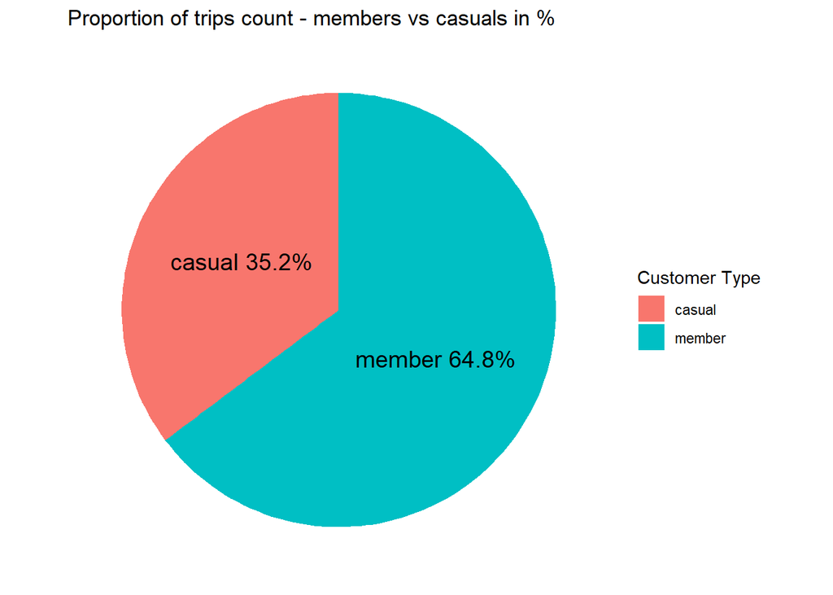

```r
ggplot(data2023_pie1, aes(x = "", y = percentage, fill = member_casual)) +
  geom_bar(width = 1, stat = "identity") +
  geom_text(aes(label = paste(member_casual, sprintf("%.1f%%", percentage))), position = position_stack(vjust = 0.5), size = 5) +
  coord_polar(theta = "y") +
  labs(fill = "Customer Type") +
  ggtitle("Proportion of trips count - members vs casuals in %") +
  theme_minimal() +
  theme(legend.position = "right",
        axis.line = element_blank(),
        axis.text = element_blank(),
        axis.title = element_blank(),
        panel.grid = element_blank())
```

#### # Aggregation for Figure 2

```r
trips_count <- data2023 %>%
  group_by(type_of_users = paste(member_casual, rideable_type)) %>%
  summarise(count = n(), .groups = 'drop')
```

### Figure 2. Pie chart for the trip number of all riders in %.

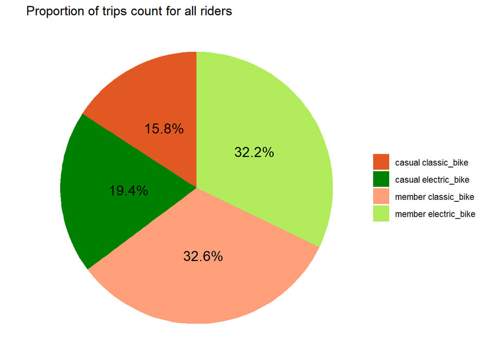

```r
ggplot(trips_count, aes(x = "", y = count, fill = type_of_users, label = sprintf("%.1f%%", count/sum(count)*100))) +
  geom_bar(width = 1, stat = "identity") +
  coord_polar(theta = "y") +
  scale_fill_manual(values = color_palette2) +
  labs(fill = "User Type") +
  ggtitle("Proportion of trips count for all riders") +
  theme_void() +
  geom_text(position = position_stack(vjust = 0.5), size = 5) +
  theme(legend.position = "right",
        legend.title = element_blank())
```

### Table 1. Members’ Trip Duration in the 97th to 100th Percentile Range:

#### Compute the quantiles in the 0.97 to 1 range

```r
percentiles1 <- seq(0.97, 1, by = 0.005)
values1 <- quantile(subset(data2023, member_casual == "member")$ride_length,
                    probs = percentiles1)
```

#### Create a data frame with percentiles and values and round the Minutes column to 1 decimal place

```r
perc_member1 <- data.frame(Percentile = percentiles1, Minutes = values1)
perc_member1$Minutes <- round(perc_member1$Minutes, 1)
```

```r
print(perc_member1)
```

```
##       Percentile Minutes
## 97%        0.970    37.5
## 97.5%      0.975    39.6
## 98%        0.980    42.1
## 98.5%      0.985    45.5
## 99%        0.990    52.1
## 99.5%      0.995    70.0
## 100%       1.000   718.1
```

### Table 2. Casuals’ Trip Duration in the 97th to 100th Percentile Range:

#### Compute the quantiles in the 0.97 to 1 range

```r
percentiles2 <- seq(0.97, 1, by = 0.005)
values2 <- quantile(subset(data2023, member_casual == "casual")$ride_length,                     probs = percentiles2)
```

#### Create a data frame with percentiles and values and round the Minutes column to 1 decimal place

```r
perc_casual2 <- data.frame(Percentile = percentiles2, Minutes = values2)
perc_casual2$Minutes <- round(perc_casual2$Minutes, 1)
```

```r
print(perc_casual2)
```

```
##       Percentile Minutes
## 97%        0.970    75.2
## 97.5%      0.975    81.4
## 98%        0.980    89.7
## 98.5%      0.985   101.2
## 99%        0.990   118.6
## 99.5%      0.995   153.2
## 100%       1.000   719.4
```

#### # Aggregation for Figure 3.

#### Group by the combination of day_of_week with member_casual

```r
count_trips7 <- data2023 %>%
  group_by(day_of_week, member_casual) %>%
  summarise(count_trips7 = n(), .groups = 'drop') %>%
  filter(!is.na(member_casual))
```

#### Convert ‘day_of_week’ to factor with custom levels in the desired order

```r
count_trips7$day_of_week <- factor(count_trips7$day_of_week, levels = c(
  "Sun", "Mon", "Tue", "Wed", "Thu", "Fri", "Sat"))
```

### Figure 3. Trip count for weekdays between members & casuals.

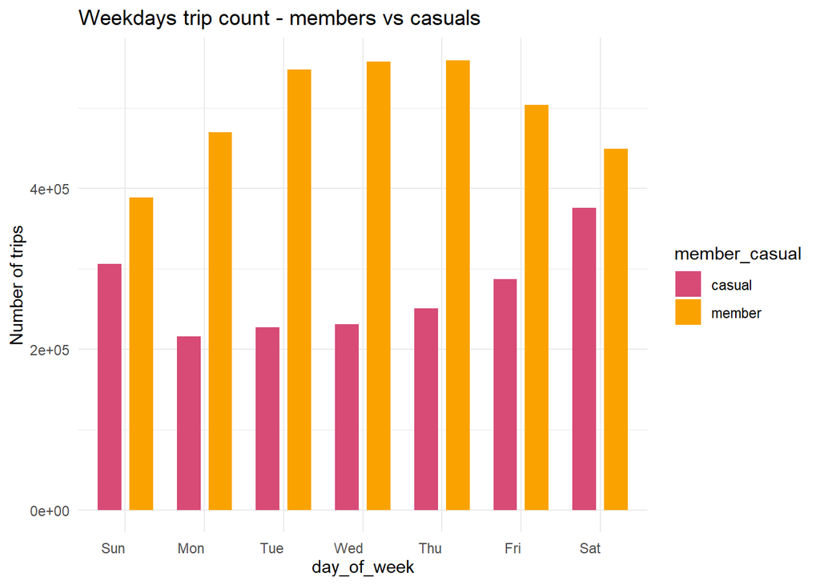

```r
ggplot(count_trips7, aes(x = day_of_week, y = count_trips7,
                         fill = member_casual)) +
  geom_bar(stat = "identity", position = position_dodge(width = 0.8),
  width = 0.6) +
  scale_fill_manual(values = color_palette1) +
  labs(title = "Weekdays trip count - members vs casuals", y = "Number of trips") +
  theme_minimal() +
   theme(axis.text.x = element_text(angle = 0, vjust = 0.5, hjust=1))
```

#### # Aggregation for Figure 4

```r
day_dur8 <- data2023 %>%
  group_by(day_of_week, member_casual) %>%
  summarise(day_dur8 = mean(ride_length), .groups = 'drop') %>%
  filter(!is.na(member_casual))
```

#### Convert ‘day_of_week’ to factor with custom levels in the desired order

```r
day_dur8$day_of_week <- factor(day_dur8$day_of_week, levels = c(
  "Sun", "Mon", "Tue", "Wed", "Thu", "Fri", "Sat"))
```

### Figure 4. Duration for weekdays between members & casuals.

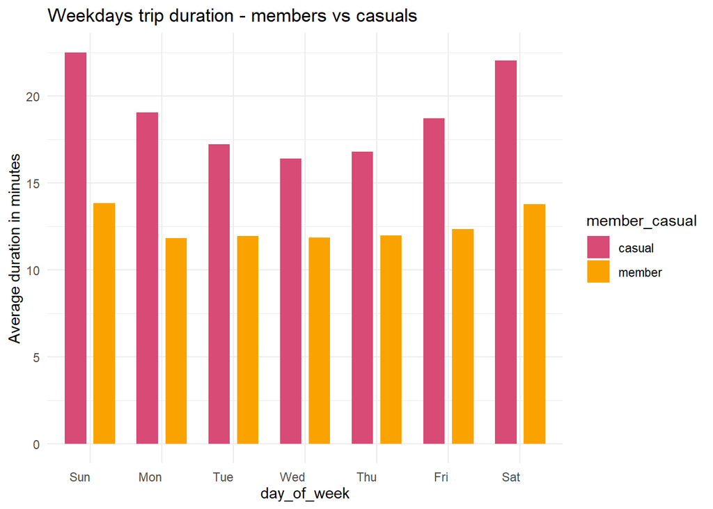

```r
ggplot(day_dur8, aes(x = day_of_week, y = day_dur8,
                         fill = member_casual)) +
  geom_bar(stat = "identity", position = position_dodge(width = 0.8),
  width = 0.6) +
  scale_fill_manual(values = color_palette1) +
  labs(title = "Weekdays trip duration - members vs casuals", y = "Average duration in minutes") +
  theme_minimal() +
   theme(axis.text.x = element_text(angle = 0, vjust = 0.5, hjust=1))
```

#### # Aggregation for Figure 5A.

```r
avg_dur1 <- data2023 %>%
  mutate(month = format(started_at, "%B")) %>%  # Extract month from started_at column
  group_by(month, member_casual) %>%
  summarise(avg_dur1 = mean(ride_length), .groups = 'drop')
```

#### Convert ‘month’ to factor with custom levels in the desired order

```r
avg_dur1$month <- factor(avg_dur1$month, levels = c(
  "January", "February", "March", "April", "May", "June",
  "July", "August", "September", "October", "November", "December"
))
```

### Figure 5A. Average trip duration for members vs casuals combined

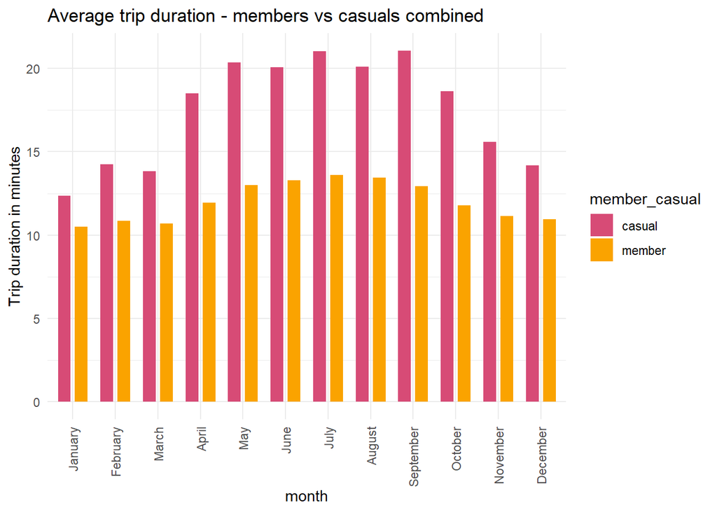

```r
ggplot(avg_dur1, aes(x = month, y = avg_dur1, fill = member_casual)) +
  geom_bar(stat = "identity", position = position_dodge(width = 0.8), width = 0.6) +
  scale_fill_manual(values = color_palette1) +
  labs(y = "Trip duration in minutes", title = "Average trip duration - members vs casuals combined") +
  theme_minimal() +
  theme(axis.text.x = element_text(angle = 90, vjust = 0.5, hjust=1))
```

#### # Aggregation for Figure 5B.

#### Group by the combination of all values from member_casual and rideable_type

```r
avg_dur2 <- data2023 %>%
  mutate(month = format(started_at, "%B")) %>%
  group_by(month, type_of_users = paste(member_casual, rideable_type)) %>%
  summarise(avg_dur2 = mean(ride_length), .groups = 'drop')
```

#### Convert ‘month’ to factor with custom levels in the desired order

```r
avg_dur2$month <- factor(avg_dur2$month, levels = c(
  "January", "February", "March", "April", "May", "June",
  "July", "August", "September", "October", "November", "December"))
```

### Figure 5B. Average trip duration & all types of bike users.

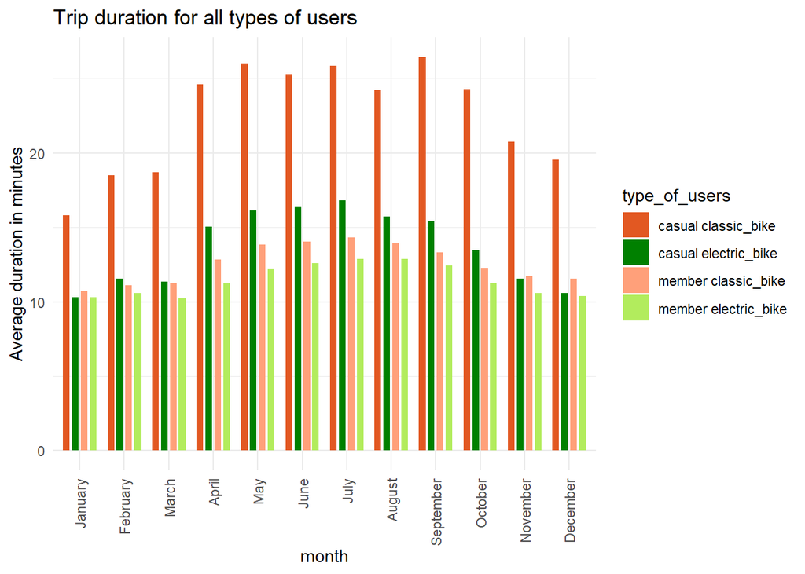

```r
ggplot(avg_dur2, aes(x = month, y = avg_dur2, fill = type_of_users)) +
  geom_bar(stat = "identity", position = position_dodge(width = 0.8), width = 0.6) +
  scale_fill_manual(values = color_palette2) +
  labs(y = "Average duration in minutes", title = "Trip duration for all types of users") +
  theme_minimal() +
  theme(axis.text.x = element_text(angle = 90, vjust = 0.5, hjust=1))
```

#### # Aggregation for Figure 6.

#### Group by the combination of classic_bike with member_casual

```r
avg_dur3 <- data2023 %>%
  mutate(month = format(started_at, "%B"),
         classic_bike_users = case_when(
           member_casual == "member" & rideable_type == "classic_bike" ~ "member_classic",
           member_casual == "casual" & rideable_type == "classic_bike" ~ "casual_classic")) %>%
  group_by(month, classic_bike_users) %>%
  summarise(avg_dur3 = mean(ride_length), .groups = 'drop') %>%
  filter(!is.na(classic_bike_users))
```

#### Convert ‘month’ to factor with custom levels in the desired order

```r
avg_dur3$month <- factor(avg_dur3$month, levels = c(
  "January", "February", "March", "April", "May", "June",
  "July", "August", "September", "October", "November", "December"))
```

### Figure 6. Average trip duration for classic_bike between members & casuals.

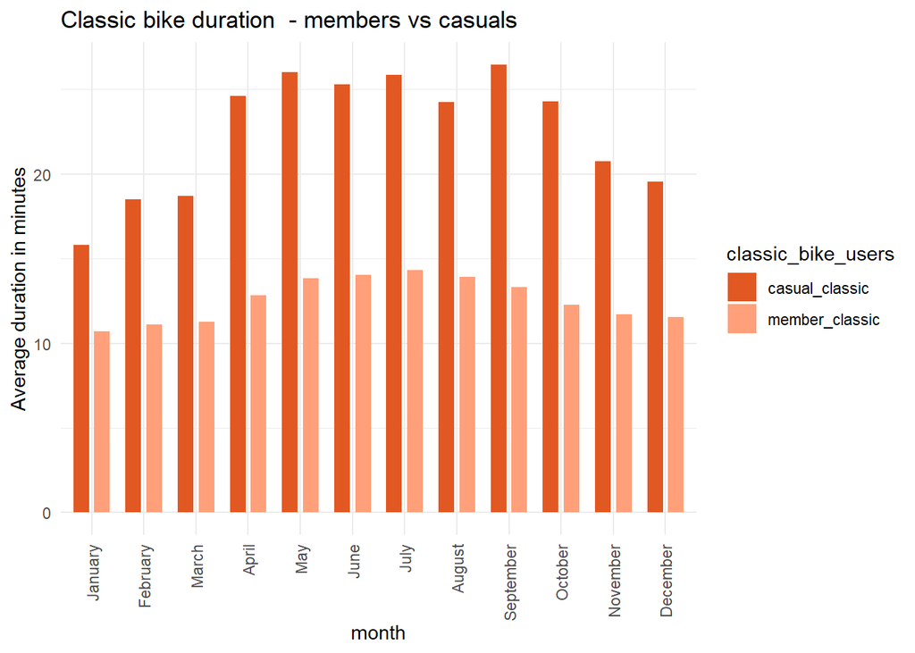

```r
ggplot(avg_dur3, aes(x = month, y = avg_dur3, fill = classic_bike_users)) +
  geom_bar(stat = "identity", position = position_dodge(width = 0.8), width = 0.6) +
  scale_fill_manual(values = color_palette3) +
  labs(y = "Average duration in minutes", title = "Classic bike duration  - members vs casuals") +
  theme_minimal() +
  theme(axis.text.x = element_text(angle = 90, vjust = 0.5, hjust=1))
```

#### # Aggregation for Figure 7.

#### Group by the combination of classic_bike with member_casual

```r
count_trips1 <- data2023 %>%
  mutate(month = format(started_at, "%B"),
         classic_bike_users = case_when(
           member_casual == "member" & rideable_type == "classic_bike" ~ "member_classic",
           member_casual == "casual" & rideable_type == "classic_bike" ~ "casual_classic")) %>%
  group_by(month, classic_bike_users) %>%
  summarise(count_trips1 = n(), .groups = 'drop') %>%
  filter(!is.na(classic_bike_users))
```

#### Convert ‘month’ to factor with custom levels in the desired order

```r
count_trips1$month <- factor(count_trips1$month, levels = c(
  "January", "February", "March", "April", "May", "June",
  "July", "August", "September", "October", "November", "December"))
```

### Figure 7. Trip count for classic_bike between members & casuals.

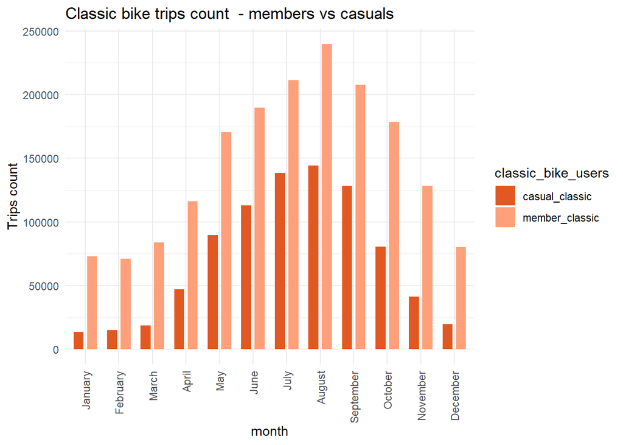

```r
ggplot(count_trips1, aes(x = month, y = count_trips1,
                         fill = classic_bike_users)) +
  geom_bar(stat = "identity", position = position_dodge(width = 0.8),
  width = 0.6) +
  scale_fill_manual(values = color_palette3) +
  labs(title = "Classic bike trips count  - members vs casuals", y = "Trips count") +
  theme_minimal() +
   theme(axis.text.x = element_text(angle = 90, vjust = 0.5, hjust=1))
```

#### # Aggregation for Figure 8.

#### Group by the combination of ‘electric_bike’ with ‘member_casual’

```r
avg_dur4 <- data2023 %>%
  mutate(month = format(started_at, "%B"),
         electric_bike_users = case_when(
           member_casual == "member" & rideable_type == "electric_bike" ~ "member_electric",
           member_casual == "casual" & rideable_type == "electric_bike" ~ "casual_electric")) %>%
  group_by(month, electric_bike_users) %>%
  summarise(avg_dur4 = mean(ride_length), .groups = 'drop') %>%
  filter(!is.na(electric_bike_users))
```

#### Convert ‘month’ to factor with custom levels in the desired order

```r
avg_dur4$month <- factor(avg_dur4$month, levels = c(
  "January", "February", "March", "April", "May", "June",
  "July", "August", "September", "October", "November", "December"))
```

### Figure 8. Average trip duration for electric_bike between members & casuals.

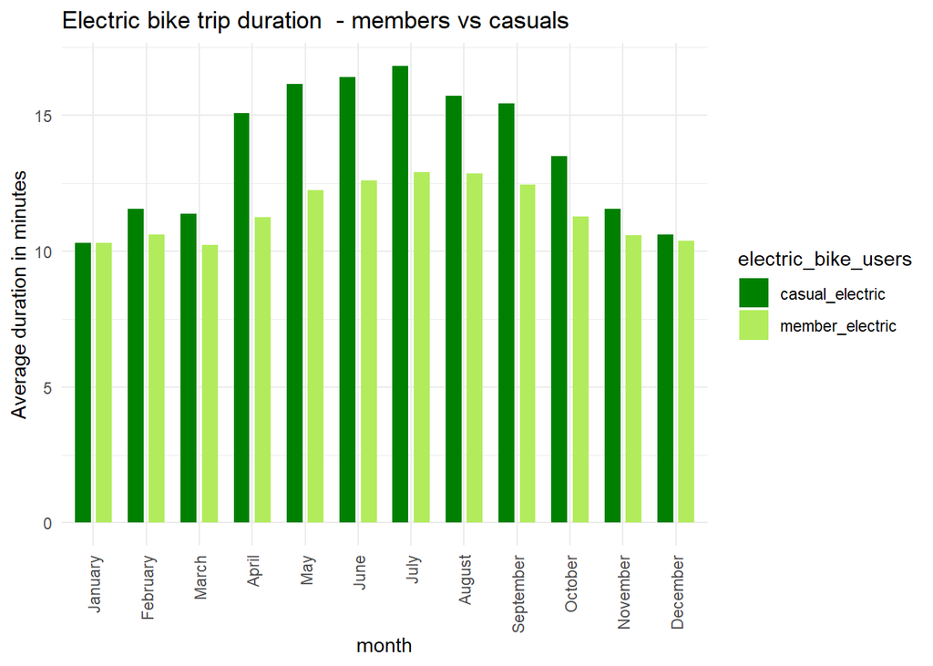

```r
ggplot(avg_dur4, aes(x = month, y = avg_dur4, fill = electric_bike_users)) +
  geom_bar(stat = "identity", position = position_dodge(width = 0.8), width = 0.6) +
  scale_fill_manual(values = color_palette4) +
  labs(y = "Average duration in minutes", title = "Electric bike trip duration  - members vs casuals") +
  theme_minimal() +
  theme(axis.text.x = element_text(angle = 90, vjust = 0.5, hjust=1))
```

#### # Aggregation for Figure 9.

#### Group by the combination of electric_bike with member_casual

```r
count_trips2 <- data2023 %>%
  mutate(month = format(started_at, "%B"),
         electric_bike_users = case_when(
           member_casual == "member" & rideable_type == "electric_bike" ~ "member_electric",
           member_casual == "casual" & rideable_type == "electric_bike" ~ "casual_electric")) %>%
  group_by(month, electric_bike_users) %>%
  summarise(count_trips2 = n(), .groups = 'drop') %>%
  filter(!is.na(electric_bike_users))
```

#### Convert ‘month’ to factor with custom levels in the desired order

```r
count_trips2$month <- factor(count_trips2$month, levels = c(
  "January", "February", "March", "April", "May", "June",
  "July", "August", "September", "October", "November", "December"))
```

### Figure 9. Trip count for electric_bike between members & casuals.

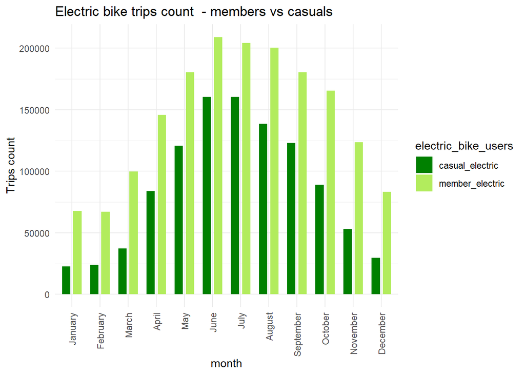

```r
ggplot(count_trips2, aes(x = month, y = count_trips2,
                         fill = electric_bike_users)) +
  geom_bar(stat = "identity", position = position_dodge(width = 0.8),
  width = 0.6) +
  scale_fill_manual(values = color_palette4) +
  labs(title = "Electric bike trips count  - members vs casuals", y = "Trips count") +
  theme_minimal() +
   theme(axis.text.x = element_text(angle = 90, vjust = 0.5, hjust=1))
```

#### # Aggregation for Figure 10.

#### Define a function to convert month to season

- Note: Function ‘month_to_season’ will be used for Figure 11 and Table 3 as well)

```r
month_to_season <- function(month) {
  case_when(
    month %in% c("January", "February", "March", "November", "December") ~ "Cold Season",
        TRUE ~ "Bike Season"
  )
}
```

#### Aggregate data by seasons

```r
tr_count_season <- data2023 %>%
  mutate(month = format(started_at, "%B")) %>%
  mutate(season = month_to_season(month)) %>%
  group_by(season, type_of_users = paste(member_casual, rideable_type)) %>%
  summarise(tr_count_season = n(), .groups = 'drop')
```

### Figure 10. Trip count with data labels for all riders by both seasons.

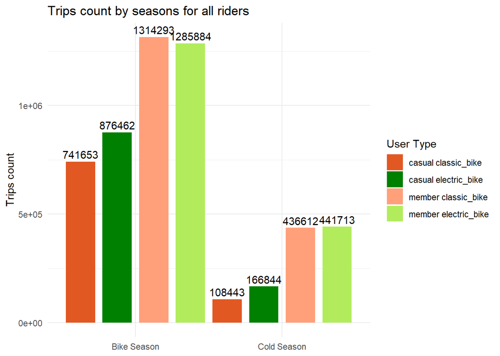

```r
ggplot(tr_count_season, aes(x = season, y = tr_count_season, fill = type_of_users, label = round(tr_count_season, 0 ))) +
  geom_bar(stat = "identity", position = position_dodge(width = 1.0), width = 0.8) +
  geom_text(position = position_dodge(width = 1.0), vjust = -0.4) +
  scale_fill_manual(values = color_palette2) +
  labs(x = NULL, y = "Trips count", title = "Trips count by seasons for all riders") +
  theme_minimal() +
  theme(axis.text.x = element_text(angle = 0, vjust = 0.5)) +
  guides(fill = guide_legend(title = "User Type"))
```

#### # Aggregate data by seasons for Figure 11.

- Note: In the next code chunk, function ‘month_to_season’ is taken from Figure 10 aggregation code block to classify months into seasons

```r
avg_dur_season <- data2023 %>%
  mutate(month = format(started_at, "%B")) %>%
  mutate(season = month_to_season(month)) %>%
  group_by(season, type_of_users = paste(member_casual, rideable_type)) %>%
  summarise(avg_dur_season = mean(ride_length), .groups = 'drop')
```

### Figure 11. Trip duration with data labels for all riders by both seasons.

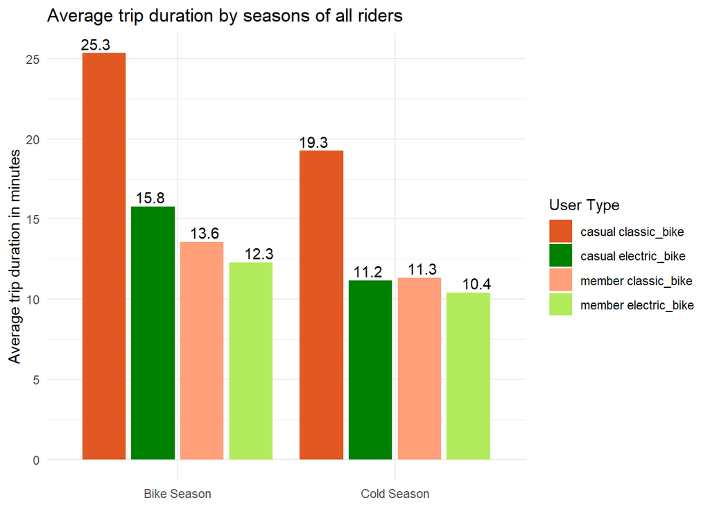

```r
ggplot(avg_dur_season, aes(x = season, y = avg_dur_season, fill = type_of_users, label = round(avg_dur_season, 1 ))) +
  geom_bar(stat = "identity", position = position_dodge(width = 0.9), width = 0.8) +
  geom_text(position = position_dodge(width = 1), vjust = -0.3) +
  scale_fill_manual(values = color_palette2) +
  labs(x = NULL, y = "Average trip duration in minutes", title = "Average trip duration by seasons of all riders") +
  theme_minimal() +
  theme(axis.text.x = element_text(angle = 0, vjust = 0.5)) +
  guides(fill = guide_legend(title = "User Type"))
```

### Table 3. Casuals’ Bike Season Trip Duration in the 60th to 100th Percentile Range

- Note: Function ‘month_to_season’ is taken from Figure 10 aggregation code block to classify months into seasons

```r
# Step 1: Extract the month and classify it into seasons
data2023 <- data2023 %>%
  mutate(
    month = format(started_at, "%B"), # Extract full month name
    season = month_to_season(month)  # Apply month_to_season function
  )

# Step 2: Filter for casual riders in Bike Season
filtered_data <- data2023 %>%
  filter(member_casual == "casual" & season == "Bike Season")

# Step 3: Create a percentiles table for ride_length
percentiles <- quantile(
  filtered_data$ride_length,
  probs = seq(0.6, 1, by = 0.05),
  na.rm = TRUE
)
# Convert the named vector into a data frame with proper column names
percentiles_table <- data.frame(
  Percentile = names(percentiles),     # Extract the names (percentiles, e.g., "60%", "65%")
  Ride_Length = round(as.numeric(percentiles), 1) # Extract the numeric values (ride lengths)
)

# Print the percentiles for Table 3
print(percentiles_table)
```

```
##   Percentile Ride_Length
## 1        60%        15.7
## 2        65%        17.6
## 3        70%        19.9
## 4        75%        22.8
## 5        80%        26.6
## 6        85%        32.2
## 7        90%        41.5
## 8        95%        61.0
## 9       100%       719.4
```

#### # Aggregation for Figure 12.

#### Create a week column and calculate the weekly ratio

```r
weekly_counts <- data2023 %>%
  mutate(week = floor_date(started_at, unit = "week")) %>%  # Create 'week' column
  group_by(week, member_casual) %>%
  summarise(count = n(), .groups = "drop") %>%
  pivot_wider(names_from = member_casual, values_from = count, values_fill = 0) %>%
  mutate(ratio = casual / member)  # Calculate the ratio
```

#### Calculate monthly averages from weekly_counts

```r
monthly_avg <- weekly_counts %>%
  mutate(month = floor_date(week, unit = "month")) %>%
  group_by(month) %>%
  summarise(monthly_ratio_avg = mean(ratio, na.rm = TRUE), .groups = "drop")
```

#### Calculate the Weighted yearly average based on weeks average

```r
yearly_avg <- mean(weekly_counts$ratio, na.rm = TRUE)
yearly_avg # Weighted Yearly (Weeks) average for Table 5
```

```
## [1] 0.4812061
```

#### Ensure all date-related columns (week and month) are in Date format:

```r
weekly_counts <- weekly_counts %>%
  mutate(
    week = as.Date(week)  # Ensure 'week' is a Date object
  )

monthly_avg <- monthly_avg %>%
  mutate(
    month = as.Date(month)  # Ensure 'month' is a Date object
  )
```

#### Group by the months in each range and calculate the averages for the ratio column:

```r
# Averages for the specified month ranges
selected_avg <- monthly_avg %>%
  mutate(
    range_label = case_when(
      month >= as.Date("2023-04-01") & month <= as.Date("2023-10-31") ~ "Bike Season",  # April to October
      month %in% c(as.Date("2023-01-01"), as.Date("2023-02-01"), as.Date("2023-03-01"),
                   as.Date("2023-11-01"), as.Date("2023-12-01")) ~ "Cold Season",  # Jan-Mar & Nov-Dec
      TRUE ~ NA_character_
    )
  ) %>%
  group_by(range_label) %>%
  summarise(avg = mean(monthly_ratio_avg, na.rm = TRUE), .groups = "drop")

# Extract specific averages into separate objects
april_oct_avg <- selected_avg %>% filter(range_label == "Bike Season") %>% pull(avg)
jan_mar_nov_dec_avg <- selected_avg %>% filter(range_label == "Cold Season") %>% pull(avg)

april_oct_avg       # Bike Season average for Table 5
```

```
## [1] 0.6097849
```

```r
jan_mar_nov_dec_avg # Cold Season average for Table 5
```

```
## [1] 0.3085346
```

### Figure 12. Weekly, monthly, yearly, and Bike and Cold seasons ratios between Casuals and Members.

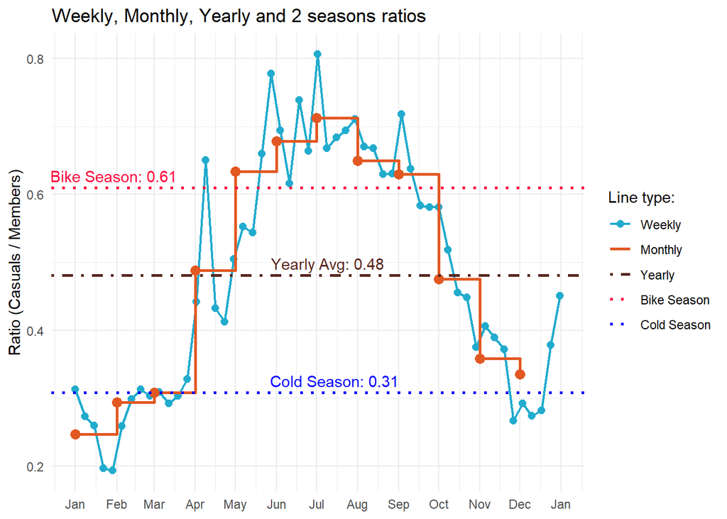

```r
ggplot(weekly_counts, aes(x = week, y = ratio, color = "Weekly")) +
  # Weekly ratio line
  geom_line(linewidth = 0.8) +
  geom_point(size = 2.2) +

  # Monthly average line
  geom_step(data = monthly_avg, aes(x = month, y = monthly_ratio_avg, color = "Monthly"),
            linewidth = 1) +
  geom_point(data = monthly_avg, aes(x = month, y = monthly_ratio_avg),
             color = "#e25822", size = 3) +  # Markers for monthly averages

  # Yearly average line
  geom_hline(aes(yintercept = yearly_avg, color = "Yearly"),
             linewidth = 1, linetype = "dotdash") +

  # Selected monthly averages
  geom_hline(data = selected_avg, aes(yintercept = avg, color = range_label),
             linetype = "dotted", linewidth = 1) +

  # Add annotations for averages
  annotate("text", x = as.Date("2023-12-01"), y = yearly_avg,
           label = paste0("Yearly Avg: ", round(yearly_avg, 2)),
           hjust = 2.2, vjust = -0.5, color = "#592720", fontface = "plain") +
  annotate("text", x = as.Date("2023-07-01"), y = april_oct_avg,
           label = paste0("Bike Season: ", round(april_oct_avg, 2)),
           hjust = 2.1, vjust = -0.5, color = "#ff033e", fontface = "plain") +
  annotate("text", x = as.Date("2023-03-01"), y = jan_mar_nov_dec_avg,
           label = paste0("Cold Season: ", round(jan_mar_nov_dec_avg, 2)),
           hjust = -0.9, vjust = -0.5, color = "#0000ff", fontface = "plain") +

  # Customize labels and legend #50c878
  labs(
    title = "Weekly, Monthly, Yearly and 2 seasons ratios",
        x = NULL,
        y = "Ratio (Casuals / Members)",
    color = "Line type:"
  ) +
  scale_color_manual(
    values = c(
      "Weekly" = "#21abcd",
      "Monthly" = "#e25822",
      "Yearly" = "#592720",
      "Bike Season" = "#ff033e",
      "Cold Season" = "#0000ff"
    ),
    breaks = c("Weekly", "Monthly", "Yearly", "Bike Season", "Cold Season"),
    labels = c("Weekly", "Monthly", "Yearly", "Bike Season", "Cold Season")
  ) +
  scale_x_date(
    date_labels = "%b",
    date_breaks = "1 month",
    limits = c(as.Date("2023-01-01"), as.Date("2023-12-31"))
  ) +
  theme_minimal()
```

### Table 4.

#### Calculation of the total trips for Bike Season and Cold Season for Casuals only:

1. Number of total trips for each season;
2. Ratio of Bike/Cold seasons;
3. Difference between Bike & Cold seasons.
- Note: The data frame ‘tr_count_season’ is from aggregation for Figure 10

```r
# 1. Filter for Casuals only and split by season
casual_season_counts <- tr_count_season %>%
  filter(str_detect(type_of_users, "casual")) %>%
  group_by(season) %>%
  summarise(total_trips = sum(tr_count_season), .groups = "drop")

# 2. Retrieve the total trips for Bike Season and Cold Season
bike_season_trips <- casual_season_counts %>%
  filter(season == "Bike Season") %>%
  pull(total_trips)

cold_season_trips <- casual_season_counts %>%
  filter(season == "Cold Season") %>%
  pull(total_trips)

# 3. Calculate the Ratio and Difference
season_ratio <- bike_season_trips / cold_season_trips  # Ratio Bike Season / Cold Season
season_difference <- bike_season_trips - cold_season_trips  # Difference Bike Season - Cold Season

# Create a table of results
results_table <- tibble(
  Metric = c("Bike Season Trips", "Cold Season Trips", "Ratio (Bike/Cold)", "Difference (Bike - Cold)"),
  Value = c(bike_season_trips, cold_season_trips, season_ratio, season_difference)
)

# Print the Table 4
print(results_table)
```

```
## # A tibble: 4 × 2
##   Metric                        Value
##   <chr>                         <dbl>
## 1 Bike Season Trips        1618115
## 2 Cold Season Trips         275287
## 3 Ratio (Bike/Cold)              5.88
## 4 Difference (Bike - Cold) 1342828
```

### Table 5.

#### Defining the Weighted Yearly Average from Monthly Averages

```r
# Create a monthly1_counts dataset with the casual-to-member ratio for each month
monthly1_counts <- data2023 %>%
  mutate(month = floor_date(started_at, unit = "month")) %>%  # Create 'month' column
  group_by(month, member_casual) %>%  # Group by month and rider type
  summarise(count = n(), .groups = "drop") %>%  # Count rides for each group
  pivot_wider(names_from = member_casual, values_from = count, values_fill = 0) %>%  # Pivot to wide format
  mutate(ratio = casual / member)  # Calculate the ratio for each month
```

#### Calculate Weighted Yearly Average (Months)

```r
yearly_avg_months <- mean(monthly1_counts$ratio, na.rm = TRUE)
yearly_avg_months # Weighted Yearly (Months) average for Table 5
```

```
## [1] 0.4842192
```

#### Assemble and Print Table 5:

#### Table 5 references values from multiple calculations:

- Figure 12: Includes ‘april_oct_avg’, ‘jan_mar_nov_dec_avg’ and ‘yearly_avg’;
- Figure 1: Includes ‘unweighted_yearly_ratio’;
- The calculation above: Includes ‘yearly_avg_months’.

```r
# Create a data frame with renamed variables
averages_table <- data.frame(
  Category = c("Bike Season (April-Oct Avg)",
               "Cold Season (Jan-Mar & Nov-Dec Avg)",
               "Weighted Yearly (Weeks)",
               "Weighted Yearly (Months)",
               "Unweighted Yearly Ratio"),
  Average = c(april_oct_avg, jan_mar_nov_dec_avg, yearly_avg, yearly_avg_months, unweighted_yearly_ratio)
)

# Print the Table 5
print(averages_table)
```

```
##                              Category   Average
## 1         Bike Season (April-Oct Avg) 0.6097849
## 2 Cold Season (Jan-Mar & Nov-Dec Avg) 0.3085346
## 3             Weighted Yearly (Weeks) 0.4812061
## 4            Weighted Yearly (Months) 0.4842192
## 5             Unweighted Yearly Ratio 0.5443153
```